# 07_assignment_chen

Evelyn Chen

9/14/2019

## Homework Assignment #7, OPTION B

### Loading libraries

```r
library(arules)
library(rtweet)
library(twitteR)
library(ROAuth)
library(jsonlite)
library(rjson)
library(tokenizers)
library(tidyverse)
library(tm)
```

```r
library(wordcloud)
```

### 1 - Create a twittR account. What is your consumerKey? What is your accessToken?

I created a twittR developer account. My consumer key is: ‘loRET5AGtazsUSuBiZldHDu9i’ My consumer secret key is ‘zFumMSYdgS0MCWFb87myR0PsPl4SgKf6t4mgEGe2VS67kW3xRE’.

The access token code is ‘1175413408557981696-AEblNvF48Tub6490ztTDyEImiLUPAy’ and the access secret code is ‘ED1KLtKPjzItKAFsWJzuDgqCegOGbeTsofJSrQV8mKuIN’.

```r
consumerKey='loRET5AGtazsUSuBiZldHDu9i'
consumerSecret='zFumMSYdgS0MCWFb87myR0PsPl4SgKf6t4mgEGe2VS67kW3xRE'
access_Token='1175413408557981696-AEblNvF48Tub6490ztTDyEImiLUPAy'
access_Secret='ED1KLtKPjzItKAFsWJzuDgqCegOGbeTsofJSrQV8mKuIN'
requestURL='https://api.twitter.com/oauth/request_token'
accessURL='https://api.twitter.com/oauth/access_token'
authURL='https://api.twitter.com/oauth/authorize'
```

### 2- Run example 07-twitterAPI.rmd. Use hashtag: Trump. What are the 5 most common words contained within collected tweets?

When I ran the 07-twitterAPI.rmd file, the 5 most common words contained with the tweets collected were - Trump, news, no, impeached, to.

### 3 - Run this RMD file and choose your favorite hashtag. Create a wordcloud using words from all collected tweets.

I decided to use a trending hashtag - #BTS. BTS is a popular K-pop band from Korea. My students are obsessed with them.

```r
setup_twitter_oauth(consumerKey,consumerSecret,access_Token,access_Secret)
```

```
## [1] "Using direct authentication"
```

```r
Search<-twitteR::searchTwitter("#BTS",n=50,since="2019-09-09")
(Search_DF <- twListToDF(Search))
```

[output not shown]

[output cut: 240 more lines]

```r
# If you wish to store the tweets in a csv file ...
TransactionTweetsFile = "tweets_BTS.csv"
(Search_DF$text[1])
```

```
## [1] "RT @btsvotingteam01: &lt; PCA: Group of 2019 &gt;\n\nTotal Estimated Tweets + RTs\n\u23f0 24 hours UPDATE \u23f0\n\n1. #BTS — 271.9K+\n2.           — 23.6K+\nGAP…"
```

```r
## Start the file
Trans <- file(TransactionTweetsFile)
## Tokenize tweets into a list of words
Tokens<-tokenizers::tokenize_words(Search_DF$text[1],stopwords = stopwords::stopwords("en"),
          lowercase = TRUE,  strip_punct = TRUE, strip_numeric = TRUE,simplify = TRUE)
## Write squished tokens
cat(unlist(str_squish(Tokens)), "\n", file=Trans, sep=",")
close(Trans)
## Append remaining lists of tokens into file
## NOTE - a list of tokens is the set of words from a Tweet
Trans <- file(TransactionTweetsFile, open = "a")
tokenList = Tokens
for(i in 2:nrow(Search_DF)){
  Tokens<-tokenize_words(Search_DF$text[i],stopwords = stopwords::stopwords("en"),
            lowercase = TRUE,  strip_punct = TRUE, simplify = TRUE)
  cat(unlist(str_squish(Tokens)), "\n", file=Trans, sep=",")
  tokenList <- c(tokenList,  unlist(str_squish(Tokens)))
}
close(Trans)
```

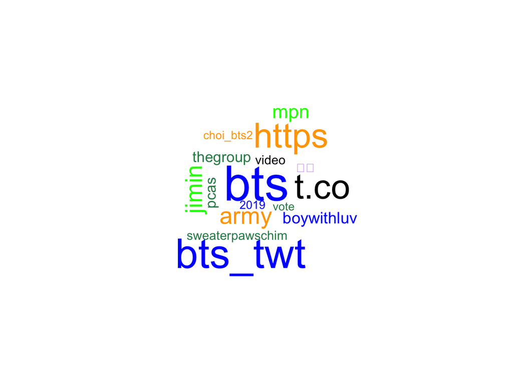

```r
# Create a wordcloud, but first transform list of words into a
# TermDocumentMatrix
cor <- Corpus(VectorSource(tokenList))
tdm <- TermDocumentMatrix(cor)
m <- as.matrix(tdm)
v <- sort(rowSums(m),decreasing=TRUE)
d <- data.frame(word = names(v),freq=v)
## NOTE:  d contains the words d$word AND frequencies d$freq
wordcloud(d$word,d$freq, colors=c("red","green","blue","orange","black","purple", "seagreen") , random.color = TRUE, min.freq = 5)
```